# *Blue Lives Matter*

- by Prachi Kharat

## 1) Objective of the proposed research-

The objective of this research is for "Blue Force Analysis" to give insights to Police enforcement officers across the nation on the four major crimes the FBI classifies as violent — homicide, rape, robbery and assault. This report depicts which areas of US are leading in the violent crimes catagory. In this report, city with maximum crimes is found and information is given about major crimes in this city over the period of time.  
This data was acquired from the FBI Uniform Crime Reporting program's "Offenses Known and Clearances by Arrest" database. This dataset include information from 68 police jurisdictions with populations of 250,000 or greater.  
This report focuses on answers to questions like 'Are violent crimes in recent years more than 80s or 90s?', Is there decrease in these crimes in modern times due to modern weapons provided to officers?

## 2) Data Exploration-

First we will read the data and print first ten rows of it to understand it.

#### First 10 rows

```python
import numpy as np
import pandas as pd
import matplotlib.pyplot as plt
import seaborn as sns
d = pd.read_csv('report.csv') # read the csv dataset
d.head(10)                    # print first 10 rows of the dataset
```

|  | report_year | agency_code | agency_jurisdiction | population | violent_crimes | homicides | rapes | assaults | robberies | months_reported | crimes_percapita | homicides_percapita | rapes_percapita | assaults_percapita | robberies_percapita |
| --- | --- | --- | --- | --- | --- | --- | --- | --- | --- | --- | --- | --- | --- | --- | --- |
| 0 | 1975 | NM00101 | Albuquerque, NM | 286238.0 | 2383.0 | 30.0 | 181.0 | 1353.0 | 819.0 | 12.0 | 832.52 | 10.48 | 63.23 | 472.68 | 286.13 |
| 1 | 1975 | TX22001 | Arlington, TX | 112478.0 | 278.0 | 5.0 | 28.0 | 132.0 | 113.0 | 12.0 | 247.16 | 4.45 | 24.89 | 117.36 | 100.46 |
| 2 | 1975 | GAAPD00 | Atlanta, GA | 490584.0 | 8033.0 | 185.0 | 443.0 | 3518.0 | 3887.0 | 12.0 | 1637.44 | 37.71 | 90.30 | 717.10 | 792.32 |
| 3 | 1975 | CO00101 | Aurora, CO | 116656.0 | 611.0 | 7.0 | 44.0 | 389.0 | 171.0 | 12.0 | 523.76 | 6.00 | 37.72 | 333.46 | 146.58 |
| 4 | 1975 | TX22701 | Austin, TX | 300400.0 | 1215.0 | 33.0 | 190.0 | 463.0 | 529.0 | 12.0 | 404.46 | 10.99 | 63.25 | 154.13 | 176.10 |
| 5 | 1975 | MD00301 | Baltimore County, MD | 642154.0 | 1259.0 | 25.0 | 137.0 | 347.0 | 750.0 | 12.0 | 196.06 | 3.89 | 21.33 | 54.04 | 116.79 |
| 6 | 1975 | MDBPD00 | Baltimore, MD | 864100.0 | 16086.0 | 259.0 | 463.0 | 6309.0 | 9055.0 | 12.0 | 1861.59 | 29.97 | 53.58 | 730.12 | 1047.91 |
| 7 | 1975 | MA01301 | Boston, MA | 616120.0 | 11386.0 | 119.0 | 453.0 | 3036.0 | 7778.0 | 12.0 | 1848.02 | 19.31 | 73.52 | 492.76 | 1262.42 |
| 8 | 1975 | NY01401 | Buffalo, NY | 422276.0 | 3350.0 | 63.0 | 192.0 | 755.0 | 2340.0 | 12.0 | 793.32 | 14.92 | 45.47 | 178.79 | 554.14 |
| 9 | 1975 | NC06001 | Charlotte, NC | 262103.0 | 1937.0 | 68.0 | 71.0 | 976.0 | 822.0 | 12.0 | 739.02 | 25.94 | 27.09 | 372.37 | 313.62 |

Now we will see what coloumns are present in the dataset so we can better understand it.

#### Names of the Columns present in the dataset

The following are the columns given in the dataset.

```python
d.columns
```

```
Index(['report_year', 'agency_code', 'agency_jurisdiction', 'population',
       'violent_crimes', 'homicides', 'rapes', 'assaults', 'robberies',
       'months_reported', 'crimes_percapita', 'homicides_percapita',
       'rapes_percapita', 'assaults_percapita', 'robberies_percapita'],
      dtype='object')
```

#### Total Rows and columns present in the dataset

```python
len(d.index) # Total number of rows
```

```
2829
```

```python
len(d.columns) # Total number of columns
```

```
15
```

This dataset has 2829 enteries along 15 columns.

#### Description of Homicides column in the dataset

```python
d['homicides'].describe()
```

```
count     2795.000000
mean       398.385331
std       2281.276402
min          1.000000
25%         32.000000
50%         64.000000
75%        131.000000
max      24703.000000
Name: homicides, dtype: float64
```

From the above output it can be seen that, 25th percentile of homicides dataset is 32  
50th percentile is 64  
75th percentile is 131.  
While the mean count is 398.

#### All the unique cities in the dataset

The following are all the states and cities included in the dataset.

```python
d['agency_jurisdiction'].unique()
```

```
array(['Albuquerque, NM', 'Arlington, TX', 'Atlanta, GA', 'Aurora, CO',
       'Austin, TX', 'Baltimore County, MD', 'Baltimore, MD',
       'Boston, MA', 'Buffalo, NY', 'Charlotte, NC', 'Chicago, IL',
       'Cincinnati, OH', 'Cleveland, OH', 'Columbus, OH', 'Dallas, TX',
       'Denver, CO', 'Detroit, MI', 'El Paso, TX', 'Fairfax County, VA',
       'Fort Worth, TX', 'Fresno, CA', 'Honolulu, HI', 'Houston, TX',
       'Indianapolis, IN', 'Jacksonville, FL', 'Kansas City, MO',
       'Las Vegas, NV', 'Long Beach, CA', 'Los Angeles County, CA',
       'Los Angeles, CA', 'Louisville, KY', 'Memphis, TN', 'Mesa, AZ',
       'Miami-Dade County, FL', 'Miami, FL', 'Milwaukee, WI',
       'Minneapolis, MN', 'Montgomery County, MD', 'Nashville, TN',
       'Nassau County, NY', 'New Orleans, LA', 'New York City, NY',
       'Newark, NJ', 'Oakland, CA', 'Oklahoma City, OK', 'Omaha, NE',
       'Orlando, FL', 'Philadelphia, PA', 'Phoenix, AZ', 'Pittsburgh, PA',
       'Portland, OR', "Prince George's County, MD", 'Raleigh, NC',
       'Sacramento, CA', 'Salt Lake City, UT', 'San Antonio, TX',
       'San Diego, CA', 'San Francisco, CA', 'San Jose, CA',
       'Seattle, WA', 'St. Louis, MO', 'Suffolk County, NY', 'Tampa, FL',
       'Tucson, AZ', 'Tulsa, OK', 'Virginia Beach, VA', 'Washington, DC',
       'Wichita, KS', 'United States'], dtype=object)
```

```python
d['agency_jurisdiction'].nunique()
```

```
69
```

There are total of 69 cities and unique values represented in the dataset.

## 3) One column Selection

The coloumn selected for this representation is Robberies as it is the most common crimes andmost difficult to solve.

The following table contains all the rows which have 10 highest counts of robberies taken place.

```python
d.nlargest(10, ['robberies'])
```

|  | report_year | agency_code | agency_jurisdiction | population | violent_crimes | homicides | rapes | assaults | robberies | months_reported | crimes_percapita | homicides_percapita | rapes_percapita | assaults_percapita | robberies_percapita |
| --- | --- | --- | --- | --- | --- | --- | --- | --- | --- | --- | --- | --- | --- | --- | --- |
| 455 | 1981 | NY03030 | New York City, NY | 7070429.0 | 156946.0 | 1826.0 | 3862.0 | 43783.0 | 107475.0 | 12.0 | 2219.75 | 25.83 | 54.62 | 619.24 | 1520.06 |
| 386 | 1980 | NY03030 | New York City, NY | 7035348.0 | 149549.0 | 1812.0 | 3711.0 | 43476.0 | 100550.0 | 12.0 | 2125.68 | 25.76 | 52.75 | 617.97 | 1429.21 |
| 1076 | 1990 | NY03030 | New York City, NY | 7322564.0 | 174542.0 | 2245.0 | 3126.0 | 68891.0 | 100280.0 | 12.0 | 2383.62 | 30.66 | 42.69 | 940.80 | 1369.47 |
| 1145 | 1991 | NY03030 | New York City, NY | 7350023.0 | 170390.0 | 2154.0 | 2892.0 | 66832.0 | 98512.0 | 12.0 | 2318.22 | 29.31 | 39.35 | 909.28 | 1340.30 |
| 524 | 1982 | NY03030 | New York City, NY | 7096559.0 | 143943.0 | 1668.0 | 3547.0 | 42784.0 | 95944.0 | 12.0 | 2028.35 | 23.50 | 49.98 | 602.88 | 1351.98 |
| 1007 | 1989 | NY03030 | New York City, NY | 7369454.0 | 169487.0 | 1905.0 | 3254.0 | 70951.0 | 93377.0 | 12.0 | 2299.86 | 25.85 | 44.16 | 962.77 | 1267.08 |
| 1214 | 1992 | NY03030 | New York City, NY | 7375097.0 | 159578.0 | 1995.0 | 2815.0 | 63529.0 | 91239.0 | 12.0 | 2163.74 | 27.05 | 38.17 | 861.40 | 1237.12 |
| 938 | 1988 | NY03030 | New York City, NY | 7346352.0 | 162916.0 | 1896.0 | 3412.0 | 71030.0 | 86578.0 | 12.0 | 2217.64 | 25.81 | 46.44 | 966.87 | 1178.52 |
| 110 | 1976 | NY03030 | New York City, NY | 7530493.0 | 134153.0 | 1622.0 | 3400.0 | 42948.0 | 86183.0 | 12.0 | 1781.46 | 21.54 | 45.15 | 570.32 | 1144.45 |
| 1283 | 1993 | NY03030 | New York City, NY | 7347257.0 | 153543.0 | 1946.0 | 2818.0 | 62778.0 | 86001.0 | 12.0 | 2089.80 | 26.49 | 38.35 | 854.44 | 1170.52 |

It can seen that NYC has seen highest number of robberies in 80s and 90s.

## Sort

Now, we will sort the dataset according to the column agency jurisdiction which has 69 unique values.

```python
new_d = pd.DataFrame(d, columns =['report_year','agency_jurisdiction','homicides_percapita','rapes_percapita','assaults_percapita','robberies_percapita'])
sort_d = new_d.sort_values('agency_jurisdiction')
sort_d.head(10)
```

|  | report_year | agency_jurisdiction | homicides_percapita | rapes_percapita | assaults_percapita | robberies_percapita |
| --- | --- | --- | --- | --- | --- | --- |
| 0 | 1975 | Albuquerque, NM | 10.48 | 63.23 | 472.68 | 286.13 |
| 621 | 1984 | Albuquerque, NM | 7.86 | 58.93 | 606.68 | 340.94 |
| 2208 | 2007 | Albuquerque, NM | 9.16 | 59.83 | 640.59 | 280.44 |
| 552 | 1983 | Albuquerque, NM | 6.76 | 58.00 | 511.03 | 255.94 |
| 2277 | 2008 | Albuquerque, NM | 7.20 | 70.15 | 561.18 | 255.94 |
| 483 | 1982 | Albuquerque, NM | 7.54 | 57.69 | 437.15 | 268.44 |
| 2346 | 2009 | Albuquerque, NM | 10.55 | 61.44 | 489.41 | 207.86 |
| 414 | 1981 | Albuquerque, NM | 13.36 | 63.23 | 480.94 | 328.64 |
| 2139 | 2006 | Albuquerque, NM | 6.79 | 57.09 | 610.63 | 233.75 |
| 2415 | 2010 | Albuquerque, NM | 7.69 | 61.92 | 544.29 | 172.21 |

## 5) Series

The column Violent crimes contain total of all the four major crimes. Now we will find total number of all violent crimes in US from 1975 to 2015

```python
d.fillna(value=0)
violent_crimes=d["violent_crimes"]
total_number_of_crimes=np.nansum(violent_crimes)
print("Total number of violent crimes in US is:",total_number_of_crimes)
```

```
Total number of violent crimes in US is: 82793331.0
```

Since NYC has the maximum number of crimes, we look further into crimes specifically in NYC.

```python
NYC = d[d.agency_jurisdiction == 'New York City, NY']
```

```
Text(0,0.5,'Number of Homicides')
```

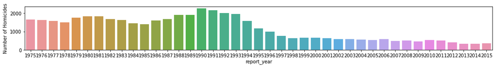

```python
plt.figure(figsize=(18,10))
h = plt.subplot(511)
sns.barplot(NYC["report_year"], NYC["homicides"])
plt.ylabel("Number of Homicides")
```

```
Text(0,0.5,'Number of Rapes')
```

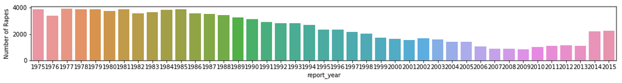

```python
plt.figure(figsize=(18,10))
R2 = plt.subplot(512)
sns.barplot(NYC["report_year"], NYC["rapes"])
plt.ylabel("Number of Rapes")
```

```
Text(0,0.5,'Number of Robberies')
```

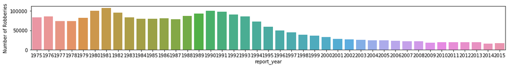

```python
plt.figure(figsize=(18,10))
R = plt.subplot(513)
sns.barplot(NYC["report_year"], NYC["robberies"])
plt.ylabel("Number of Robberies")
```

```
Text(0,0.5,'Number of Assaults')
```

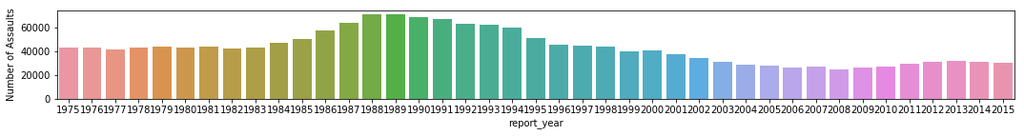

```python
plt.figure(figsize=(18,10))
a = plt.subplot(514)
sns.barplot(NYC["report_year"], NYC["assaults"])
plt.ylabel("Number of Assaults")
```

```python
dv=NYC[NYC["report_year"]>2009]
```

```python
dv.head(5)
```

|  | report_year | agency_code | agency_jurisdiction | population | violent_crimes | homicides | rapes | assaults | robberies | months_reported | crimes_percapita | homicides_percapita | rapes_percapita | assaults_percapita | robberies_percapita |
| --- | --- | --- | --- | --- | --- | --- | --- | --- | --- | --- | --- | --- | --- | --- | --- |
| 2456 | 2010 | NY03030 | New York City, NY | 8175133.0 | 48489.0 | 536.0 | 1036.0 | 27309.0 | 19608.0 | 12.0 | 593.13 | 6.56 | 12.67 | 334.05 | 239.85 |
| 2525 | 2011 | NY03030 | New York City, NY | 8211875.0 | 51209.0 | 515.0 | 1092.0 | 29829.0 | 19773.0 | 12.0 | 623.60 | 6.27 | 13.30 | 363.24 | 240.79 |
| 2594 | 2012 | NY03030 | New York City, NY | 8289415.0 | 52993.0 | 419.0 | 1162.0 | 31211.0 | 20201.0 | 12.0 | 639.29 | 5.05 | 14.02 | 376.52 | 243.70 |
| 2663 | 2013 | NY03030 | New York City, NY | 8396126.0 | 52384.0 | 335.0 | 1112.0 | 31767.0 | 19170.0 | 12.0 | 623.91 | 3.99 | 13.24 | 378.35 | 228.32 |
| 2732 | 2014 | NY03030 | New York City, NY | 8473938.0 | 50564.0 | 333.0 | 2190.0 | 31460.0 | 16581.0 | 12.0 | 596.70 | 3.93 | 25.84 | 371.26 | 195.67 |

## 6) Plot

```
[Text(0,0.5,'City'), Text(0.5,0,'Total number of crimes')]
```

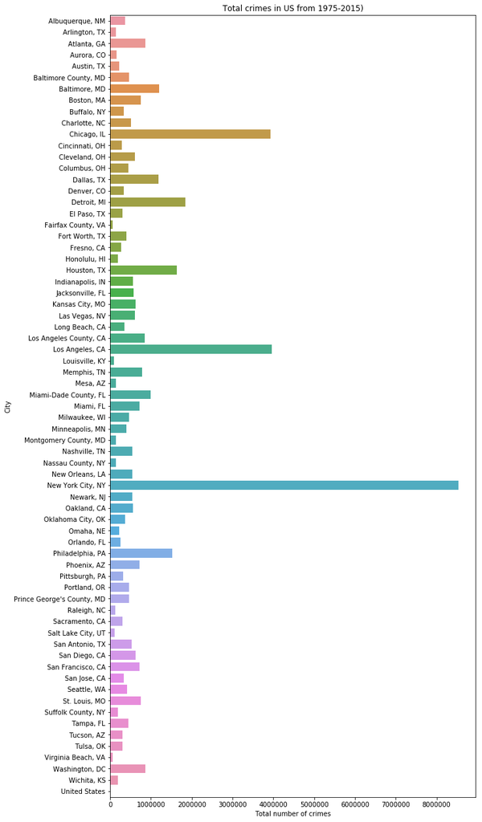

```python
ax=plt.figure(figsize=(10,22))
ax = sns.barplot(d["violent_crimes"]+d["homicides"]+
                 d["rapes"]+d["assaults"]+d["robberies"],
                 y=d["agency_jurisdiction"],estimator=sum ,ci=0)
ax.set_title('Total crimes in US from 1975-2015)')
ax.set(xlabel='Total number of crimes', ylabel='City')
```

The above plot shows the total of all the crimes in all the cities to find which city has most number of crimes.